# Alpha Diversity

NP

06/22/2018

Initialize:

```r
library("phyloseq"); packageVersion("phyloseq")
```

```
## [1] '1.22.3'
```

```r
library("ggplot2"); packageVersion("ggplot2")
```

```
## [1] '2.2.1'
```

```r
library("gridExtra")
library(grid)
library(picante)
library("igraph"); packageVersion("igraph")
```

```
## [1] '1.2.1'
```

```r
set.seed(20180116)
default.par <- par(no.readonly = TRUE)
options(stringsAsFactors = FALSE)
theme_set(theme_bw())
```

Load data:

```r
# Set working directory to source file location
setwd("~/Box Sync/Research/CRC BMI Meta/Compiled Code & Results/Alpha Diversity")
load("~/Box Sync/Research/CRC BMI Meta/Compiled Code & Results/Data/CRC_BMI_DATA.RData")
load("~/Box Sync/Research/CRC BMI Meta/Compiled Code & Results/Data/16S.wk.RData")

stored_dat <- list(baxter.stool.data.obj.wk, zackular.stool.data.obj.wk, zeller.stool.data.obj.wk, zeller.tissue.data.obj.wk)
names(stored_dat) <- c("baxter", "zackular", "zeller.Stool", "zeller.Tissue")
```

# Organization of Data Objects

The objects in the workspace object CRC_BMI_DATA.RData are organized as follows. The lists below are split based on the sequencing type. All objects have been put into a phyloseq objects based on the phyloseq package. * 16S sequencing data objects + OTU Table (otu_table) - Rows are taxa names - Columns are samples + Taxanomic Table (tax_table) - Rows are same ad the OTU Table with all taxa names - Columns are which level of the taxonomy and what the name under that taxa. + Sample Data (sam_data) - gives details of each sample (meta-data) - identifiers for subsetting based on BMI or other group + Phylogenic Tree (phy_tree) * WGS data objects + OTU Table (otu_table) - Rows are taxa names - Columns are samples + Sample Data * Pooled Data + Contains the taxonomy of all samples from all studies included + Sample data contains BMI, BMI Category and Cancer identifier

# Alpha diversity in Obese vs Non-Obese with or without CRC

```r
my_phylo <- myphylo
datasets <- names(myphylo)

# Estimate alpha diversity metrics: this loop also combines the etimates
# with the sample data to create a dataframe for each study that includes
# alpha diversity
estAlpha <- list()
bp_CRC <- list()
bp_nonCRC <- list()
man_U_Tests <- list()
for (df in datasets) {
    # df <- 'baxter'
    dat <- prune_species(speciesSums(my_phylo[[df]]) > 1, my_phylo[[df]])

    estAlpha[[df]] <- estimate_richness(dat, measures = c("Observed", "Shannon",
        "InvSimpson"))

    # Faith's phylogenetic diversity metric Not supported by phyloseq package
    # Need phylogenetic tree if(df == 'baxter'| df = 'zackular'| df =
    # 'zeller.Stool'| df = 'zeller.Tissue'){ estAlpha[[df]]$faithPD <-
    # pd(stored_dat[[df]]$otu.tab, stored_dat[[df]]$tree) }


    estAlpha[[df]] <- cbind(sample_data(dat), estAlpha[[df]])

    # boxplots for alpha by CRC and non-CRC subset to CRC
    subdat <- na.omit(estAlpha[[df]][estAlpha[[df]]$Status == "CRC", ])

    bp_CRC[[paste0(df, ".", "Observed")]] <- ggplot(subdat, aes(x = BMI_Cat,
        y = Observed)) + geom_boxplot(outlier.alpha = 0, aes(color = BMI_Cat)) +
        geom_point(alpha = 0.5, aes(fill = BMI_Cat, color = BMI_Cat), position = position_jitterdodge()) +
        ylim(0, 600) + theme_minimal() + coord_flip()

    bp_CRC[[paste0(df, ".", "Shannon")]] <- ggplot(subdat, aes(x = BMI_Cat,
        y = Shannon)) + geom_boxplot(outlier.alpha = 0, aes(color = BMI_Cat)) +
        geom_point(alpha = 0.5, aes(fill = BMI_Cat, color = BMI_Cat), position = position_jitterdodge()) +
        ylim(0, 5) + theme_minimal() + coord_flip()

    man_U_Tests[[paste0(df, ".", "CRC", ".", "Observed")]] <- wilcox.test(Observed ~
        BMI_Cat, data = subdat)
    man_U_Tests[[paste0(df, ".", "CRC", ".", "Shannon")]] <- wilcox.test(Shannon ~
        BMI_Cat, data = subdat)

    # subset to Non-CRC
    subdat <- estAlpha[[df]][estAlpha[[df]]$Status != "CRC", ]

    bp_nonCRC[[paste0(df, ".", "Observed")]] <- ggplot(subdat, aes(BMI_Cat,
        Observed)) + geom_boxplot(outlier.alpha = 0, aes(color = BMI_Cat)) +
        geom_point(alpha = 0.5, aes(fill = BMI_Cat, color = BMI_Cat), position = position_jitterdodge()) +
        ylim(0, 600) + theme_minimal() + coord_flip()

    bp_nonCRC[[paste0(df, ".", "Shannon")]] <- ggplot(subdat, aes(x = BMI_Cat,
        y = Shannon)) + geom_boxplot(outlier.alpha = 0, aes(color = BMI_Cat)) +
        geom_point(alpha = 0.5, aes(fill = BMI_Cat, color = BMI_Cat), position = position_jitterdodge()) +
        ylim(0, 5) + theme_minimal() + coord_flip()

    man_U_Tests[[paste0(df, ".", "nonCRC", ".", "Observed")]] <- wilcox.test(Observed ~
        BMI_Cat, data = subdat)
    man_U_Tests[[paste0(df, ".", "nonCRC", ".", "Shannon")]] <- wilcox.test(Shannon ~
        BMI_Cat, data = subdat)
}  # End make Box plots
```

# Results from Man-Whitney-U Tests

```r
type <- c("CRC", "nonCRC")

results.mwu <- matrix(0, nrow = 16, ncol = 2)
i <- 1
for (df in datasets) {
    for (ty in type) {

        results.mwu[i, ] <- as.matrix(c(man_U_Tests[[paste0(df, ".", ty, ".",
            "Observed")]]$p.value, man_U_Tests[[paste0(df, ".", ty, ".", "Shannon")]]$p.value),
            ncol = 2)
        i = i + 1
    }
}

row.names(results.mwu) <- c("baxter.CRC", "baxter.nonCRC", "zackular.CRC", "zackular.nonCRC",
    "zeller.Stool.CRC", "zeller.Stool.nonCRC", "zeller.Tissue.CRC", "zeller.Tissue.nonCRC",
    "feng.CRC", "feng.nonCRC", "voghtmann.CRC", "voghtmann.nonCRC", "zeller.WGS.CRC",
    "zeller.WGS.nonCRC", "Pooled.CRC", "Pooled.nonCRC")
colnames(results.mwu) <- c("Observed", "Shannon")
results.mwu <- round(results.mwu, 3)
print(results.mwu)
```

```
##                      Observed Shannon
## baxter.CRC              0.742   0.696
## baxter.nonCRC           0.009   0.003
## zackular.CRC            0.384   0.424
## zackular.nonCRC         0.638   0.418
## zeller.Stool.CRC        0.135   0.137
## zeller.Stool.nonCRC     0.021   0.012
## zeller.Tissue.CRC       0.370   0.942
## zeller.Tissue.nonCRC    0.310   0.510
## feng.CRC                0.463   0.861
## feng.nonCRC             0.939   0.519
## voghtmann.CRC           0.293   0.985
## voghtmann.nonCRC        0.805   0.809
## zeller.WGS.CRC          0.079   0.971
## zeller.WGS.nonCRC       0.088   0.144
## Pooled.CRC              0.101   0.059
## Pooled.nonCRC           0.002   0.000
```

# Figure 1 parts

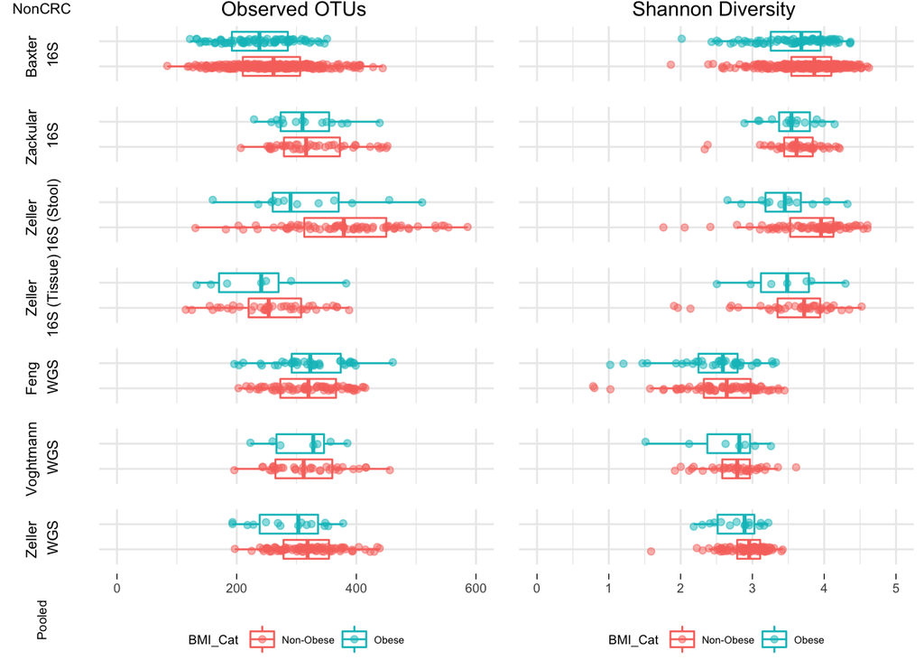

```r
# Make text boxes
p1 <- textGrob("NonCRC", gp=gpar(fontsize=8, col="black"))
p2 <- textGrob("CRC", gp=gpar(fontsize=8, col="black"))
xlab1 <- textGrob("Observed OTUs", gp=gpar(fontsize=11, col="black"))
xlab2 <- textGrob("Shannon Diversity", gp=gpar(fontsize=11, col="black"))

ylab1 <- textGrob("Baxter\n 16S", rot=90, gp=gpar(fontsize=8, col="black"))
ylab2 <- textGrob("Zackular\n 16S", rot=90, gp=gpar(fontsize=8, col="black"))
ylab3 <- textGrob("Zeller\n 16S (Stool)", rot=90, gp=gpar(fontsize=8, col="black"))
ylab4 <- textGrob("Zeller\n 16S (Tissue)", rot=90, gp=gpar(fontsize=8, col="black"))
ylab5 <- textGrob("Feng\n WGS", rot=90, gp=gpar(fontsize=8, col="black"))
ylab6 <- textGrob("Voghtmann\n WGS", rot=90, gp=gpar(fontsize=8, col="black"))
ylab7 <- textGrob("Zeller\n WGS", rot=90, gp=gpar(fontsize=8, col="black"))
ylab8 <- textGrob("Pooled", rot=90, gp=gpar(fontsize=7, col="black"))


# Define Mann-Whitney-U p-values
pv11 <- textGrob(paste0("    ",results.mwu[1,1]),rot=90, gp=gpar(fontsize=8, col="black"))
pv12 <- textGrob(paste0("    ",results.mwu[1,2]),rot=90, gp=gpar(fontsize=8, col="black"))
pv21 <- textGrob(paste0("    ",results.mwu[2,1]),rot=90, gp=gpar(fontsize=8, col="black"))
pv22 <- textGrob(paste0("    ",results.mwu[2,2]),rot=90, gp=gpar(fontsize=8, col="black"))
pv31 <- textGrob(paste0("    ",results.mwu[3,1]),rot=90, gp=gpar(fontsize=8, col="black"))
pv32 <- textGrob(paste0("    ",results.mwu[3,2]),rot=90, gp=gpar(fontsize=8, col="black"))
pv41 <- textGrob(paste0("    ",results.mwu[4,1]),rot=90, gp=gpar(fontsize=8, col="black"))
pv42 <- textGrob(paste0("    ",results.mwu[4,2]),rot=90, gp=gpar(fontsize=8, col="black"))
pv51 <- textGrob(paste0("    ",results.mwu[5,1]),rot=90, gp=gpar(fontsize=8, col="black"))
pv52 <- textGrob(paste0("    ",results.mwu[5,2]),rot=90, gp=gpar(fontsize=8, col="black"))
pv61 <- textGrob(paste0("    ",results.mwu[6,1]),rot=90, gp=gpar(fontsize=8, col="black"))
pv62 <- textGrob(paste0("    ",results.mwu[6,2]),rot=90, gp=gpar(fontsize=8, col="black"))
pv71 <- textGrob(paste0("    ",results.mwu[7,1]),rot=90, gp=gpar(fontsize=8, col="black"))
pv72 <- textGrob(paste0("    ",results.mwu[7,2]),rot=90, gp=gpar(fontsize=8, col="black"))
pv81 <- textGrob(paste0("    ",results.mwu[8,1]),rot=90, gp=gpar(fontsize=8, col="black"))
pv82 <- textGrob(paste0("    ",results.mwu[8,2]),rot=90, gp=gpar(fontsize=8, col="black"))
pv91 <- textGrob(paste0("    ",results.mwu[9,1]),rot=90, gp=gpar(fontsize=8, col="black"))
pv92 <- textGrob(paste0("    ",results.mwu[9,2]),rot=90, gp=gpar(fontsize=8, col="black"))
pv101 <- textGrob(paste0("    ",results.mwu[10,1]),rot=90, gp=gpar(fontsize=8, col="black"))
pv102 <- textGrob(paste0("    ",results.mwu[10,2]),rot=90, gp=gpar(fontsize=8, col="black"))
pv111 <- textGrob(paste0("    ",results.mwu[11,1]),rot=90, gp=gpar(fontsize=8, col="black"))
pv112 <- textGrob(paste0("    ",results.mwu[11,2]),rot=90, gp=gpar(fontsize=8, col="black"))
pv121 <- textGrob(paste0("    ",results.mwu[12,1]),rot=90, gp=gpar(fontsize=8, col="black"))
pv122 <- textGrob(paste0("    ",results.mwu[12,2]),rot=90, gp=gpar(fontsize=8, col="black"))
pv131 <- textGrob(paste0("    ",results.mwu[13,1]),rot=90, gp=gpar(fontsize=8, col="black"))
pv132 <- textGrob(paste0("    ",results.mwu[13,2]),rot=90, gp=gpar(fontsize=8, col="black"))
pv141 <- textGrob(paste0("    ",results.mwu[14,1]),rot=90, gp=gpar(fontsize=8, col="black"))
pv142 <- textGrob(paste0("    ",results.mwu[14,2]),rot=90, gp=gpar(fontsize=8, col="black"))
pv151 <- textGrob(paste0("    ",results.mwu[15,1]),rot=90, gp=gpar(fontsize=8, col="black"))
pv152 <- textGrob(paste0("    ",results.mwu[15,2]),rot=90, gp=gpar(fontsize=8, col="black"))
pv161 <- textGrob(paste0("    ", results.mwu[16,1]),rot=90, gp=gpar(fontsize=8, col="black"))
pv162 <- textGrob(paste0("    < 0.001"),rot=90, gp=gpar(fontsize=8, col="black"))


# defining grob formating
gwidths <- c(unit(.6, "mm"), rep(unit(3,"in"), 2)) # 3 columns
gheights <- c(unit(1, "mm"), rep(unit(5,"in"), 8)) # 5 rows
blank_theme <- theme(legend.position = "none",
                     text = element_blank(),
                     axis.text.y = element_blank(),
                     axis.ticks.y = element_blank(),
                     axis.text.x = element_blank(),
                     axis.ticks.x = element_blank()#,
                     # panel.grid.major = element_blank(),
                     # panel.grid.minor = element_blank()
                     )

ptheme <- theme(text = element_text(size=7),
                legend.position = "bottom",
                axis.title.x = element_blank(),
                axis.title.y = element_blank(),
                axis.text.x = element_text(size=7),
                axis.text.y = element_blank(),
                # panel.grid.major = element_blank(),
                # panel.grid.minor = element_blank(),
                axis.ticks.x = element_line(size = .25))

fig1a <- grid.arrange(
   p1, xlab1, xlab2,
   ylab1,
   bp_nonCRC[[paste0("baxter",".Observed")]] + blank_theme,
   bp_nonCRC[[paste0("baxter", ".Shannon")]] + blank_theme,
   ylab2,
   bp_nonCRC[[paste0("zackular", ".Observed")]] + blank_theme ,
   bp_nonCRC[[paste0("zackular", ".Shannon")]] + blank_theme ,
   ylab3,
   bp_nonCRC[[paste0("zeller.Stool", ".Observed")]] + blank_theme ,
   bp_nonCRC[[paste0("zeller.Stool", ".Shannon")]] + blank_theme ,
   ylab4,
   bp_nonCRC[[paste0("zeller.Tissue", ".Observed")]] + blank_theme ,
   bp_nonCRC[[paste0("zeller.Tissue", ".Shannon")]] + blank_theme,
   ylab5,
   bp_nonCRC[[paste0("feng", ".Observed")]] + blank_theme ,
   bp_nonCRC[[paste0("feng", ".Shannon")]] + blank_theme,
   ylab6,
   bp_nonCRC[[paste0("voghtmann", ".Observed")]] + blank_theme ,
   bp_nonCRC[[paste0("voghtmann", ".Shannon")]] + blank_theme,
   ylab7,
   bp_nonCRC[[paste0("zeller.WGS", ".Observed")]] + blank_theme ,
   bp_nonCRC[[paste0("zeller.WGS", ".Shannon")]] + blank_theme,
   ylab8,
   bp_nonCRC[[paste0("pooled", ".Observed")]] + ptheme ,
   bp_nonCRC[[paste0("pooled", ".Shannon")]] + ptheme,

   ncol = 3, widths = gwidths, heights = gheights)
```

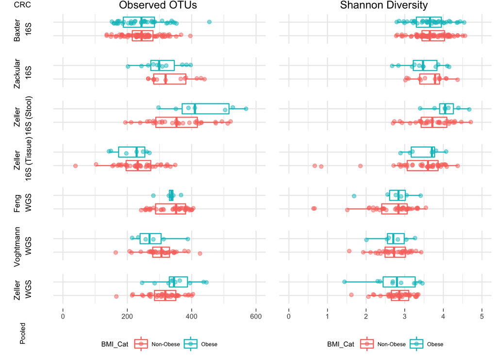

```r
# ggsave(fig1a, file = "crc_bmi_supfig1a.pdf", width=6, height=7, units=c("in"))

# Part B
fig1b <- grid.arrange(
   p2, xlab1, xlab2,
   ylab1,
   bp_CRC[[paste0("baxter",".Observed")]] + blank_theme,
   bp_CRC[[paste0("baxter", ".Shannon")]] + blank_theme,
   ylab2,
   bp_CRC[[paste0("zackular", ".Observed")]] + blank_theme ,
   bp_CRC[[paste0("zackular", ".Shannon")]] + blank_theme ,
   ylab3,
   bp_CRC[[paste0("zeller.Stool", ".Observed")]] + blank_theme ,
   bp_CRC[[paste0("zeller.Stool", ".Shannon")]] + blank_theme ,
   ylab4,
   bp_CRC[[paste0("zeller.Tissue", ".Observed")]] + blank_theme ,
   bp_CRC[[paste0("zeller.Tissue", ".Shannon")]] + blank_theme,
   ylab5,
   bp_CRC[[paste0("feng", ".Observed")]] + blank_theme ,
   bp_CRC[[paste0("feng", ".Shannon")]] + blank_theme,
   ylab6,
   bp_CRC[[paste0("voghtmann", ".Observed")]] + blank_theme ,
   bp_CRC[[paste0("voghtmann", ".Shannon")]] + blank_theme,
   ylab7,
   bp_CRC[[paste0("zeller.WGS", ".Observed")]] + blank_theme ,
   bp_CRC[[paste0("zeller.WGS", ".Shannon")]] + blank_theme,
   ylab8,
   bp_CRC[[paste0("pooled", ".Observed")]] + ptheme ,
   bp_CRC[[paste0("pooled", ".Shannon")]] + ptheme,

   ncol = 3, widths = gwidths, heights = gheights)
```

```r
# fig1
# ggsave(fig1b, file = "crc_bmi_fig1b.pdf", width=6, height=7, units=c("in"))
```

# Full Figure 1

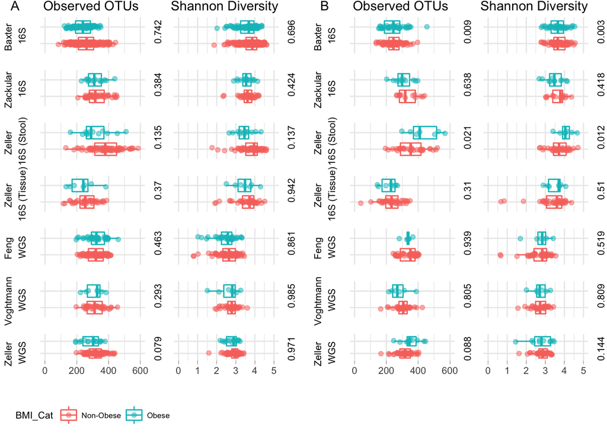

```r
p1 <- textGrob("A", gp=gpar(fontsize=11, col="black"))
p2 <- textGrob("B", gp=gpar(fontsize=11, col="black"))
BLANK <- textGrob(" ", gp=gpar(fontsize=8, col="black"))

# defining grob formating
gwidths <- c(unit(.25, "mm"), unit(1,"in"), unit(.1, "mm"),unit(1,"in"), rep(unit(.1, "mm"),2),unit(.25,"mm"), unit(1, "in"), unit(.1, "mm"),unit(1,"in"), unit(.1, "mm")) # 11 columns
gheights <- c(unit(.2, "mm"), rep(unit(1,"in"), 8)) # 8 rows

ptheme <- theme(text = element_text(size=8),
                legend.position = "none",
                axis.title.x = element_blank(),
                axis.title.y = element_blank(),
                axis.text.x = element_text(size=8),
                axis.text.y = element_blank(),
                axis.ticks.x = element_line(size = .1))
ptheme1 <- theme(text = element_text(size=8),
                legend.position = "bottom",
                axis.title.x = element_blank(),
                axis.title.y = element_blank(),
                axis.text.x = element_blank(),
                axis.text.y = element_blank(),
                axis.ticks.x = element_blank())

# Combined:
fig <- grid.arrange(
    p1, xlab1, BLANK, xlab2,BLANK,BLANK, p2, xlab1,BLANK, xlab2,BLANK,

    # Row 2
    ylab1,
    bp_nonCRC[[paste0("baxter",".Observed")]] + blank_theme,
    pv11,
    bp_nonCRC[[paste0("baxter", ".Shannon")]] + blank_theme,
    pv12,
    BLANK,
    ylab1,
    bp_CRC[[paste0("baxter",".Observed")]] + blank_theme,
    pv21,
    bp_CRC[[paste0("baxter", ".Shannon")]] + blank_theme,
    pv22,

    ylab2,
    bp_nonCRC[[paste0("zackular", ".Observed")]] + blank_theme ,
    pv31,
    bp_nonCRC[[paste0("zackular", ".Shannon")]] + blank_theme ,
    pv32,
    BLANK,
    ylab2,
    bp_CRC[[paste0("zackular", ".Observed")]] + blank_theme ,
    pv41,
    bp_CRC[[paste0("zackular", ".Shannon")]] + blank_theme ,
    pv42,

    ylab3,
    bp_nonCRC[[paste0("zeller.Stool", ".Observed")]] + blank_theme ,
    pv51,
    bp_nonCRC[[paste0("zeller.Stool", ".Shannon")]] + blank_theme ,
    pv52,
    BLANK,
    ylab3,
    bp_CRC[[paste0("zeller.Stool", ".Observed")]] + blank_theme ,
    pv61,
    bp_CRC[[paste0("zeller.Stool", ".Shannon")]] + blank_theme ,
    pv62,

    ylab4,
    bp_nonCRC[[paste0("zeller.Tissue", ".Observed")]] + blank_theme ,
    pv71,
    bp_nonCRC[[paste0("zeller.Tissue", ".Shannon")]] + blank_theme,
    pv72,
    BLANK,
    ylab4,
    bp_CRC[[paste0("zeller.Tissue", ".Observed")]] + blank_theme ,
    pv81,
    bp_CRC[[paste0("zeller.Tissue", ".Shannon")]] + blank_theme,
    pv82,

    ylab5,
    bp_nonCRC[[paste0("feng", ".Observed")]] + blank_theme ,
    pv91,
    bp_nonCRC[[paste0("feng", ".Shannon")]] + blank_theme,
    pv92,
    BLANK,
    ylab5,
    bp_CRC[[paste0("feng", ".Observed")]] + blank_theme ,
    pv101,
    bp_CRC[[paste0("feng", ".Shannon")]] + blank_theme,
    pv102,

    ylab6,
    bp_nonCRC[[paste0("voghtmann", ".Observed")]] + blank_theme ,
    pv111,
    bp_nonCRC[[paste0("voghtmann", ".Shannon")]] + blank_theme,
    pv112,
    BLANK,
    ylab6,
    bp_CRC[[paste0("voghtmann", ".Observed")]] + blank_theme ,
    pv121,
    bp_CRC[[paste0("voghtmann", ".Shannon")]] + blank_theme,
    pv122,

    ylab7,
    bp_nonCRC[[paste0("zeller.WGS", ".Observed")]] + ptheme,
    pv131,
    bp_nonCRC[[paste0("zeller.WGS", ".Shannon")]] + ptheme,
    pv132,
    BLANK,
    ylab7,
    bp_CRC[[paste0("zeller.WGS", ".Observed")]] + ptheme ,
    pv141,
    bp_CRC[[paste0("zeller.WGS", ".Shannon")]] + ptheme,
    pv142,

    BLANK, bp_CRC[[paste0("zeller.WGS", ".Shannon")]] + ptheme1,
    BLANK,BLANK,BLANK,BLANK,BLANK,BLANK,BLANK,BLANK,BLANK,

    ncol = 11, widths = gwidths, heights = gheights
)
```

```r
ggsave(fig, file = "crc_bmi_fig1.pdf", width=6, height=5, units=c("in"))
```

# Supplemental Figure 1: Scatterplots

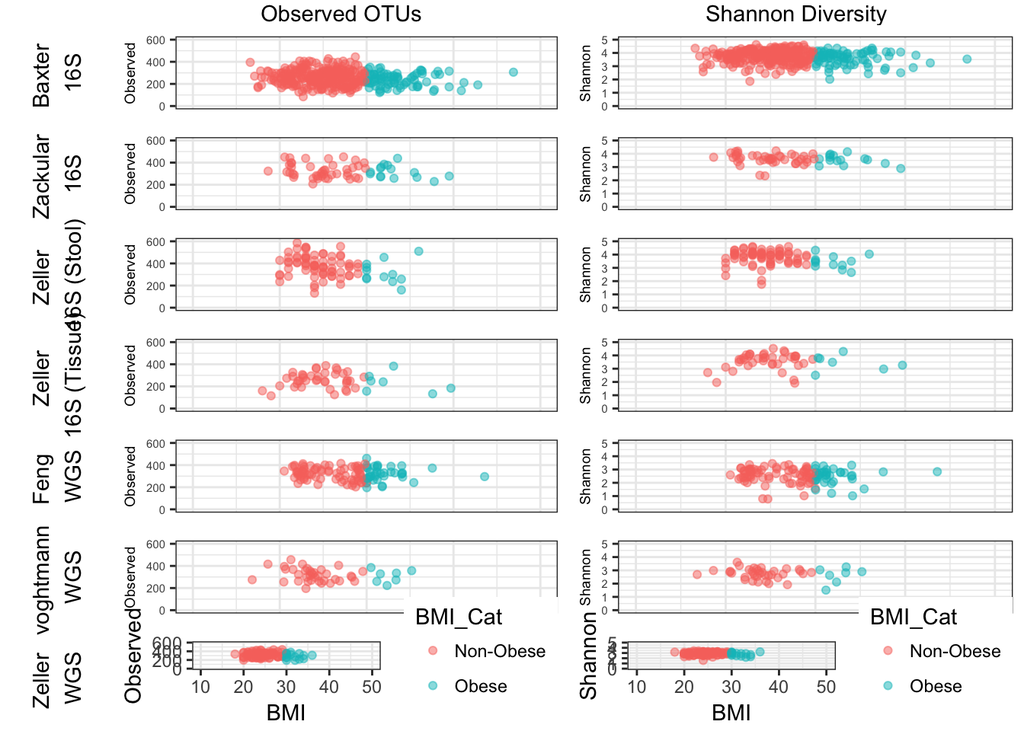

```r
sp_CRC <- list()
sp_nonCRC <- list()
for(df in datasets)
{
    # subset to CRC
    subdat <- na.omit(estAlpha[[df]][estAlpha[[df]]$Status == "CRC",])

    sp_CRC[[paste0(df, ".","Observed")]] <- ggplot(subdat, aes(x = BMI, y = Observed, color = BMI_Cat)) +
        geom_point(alpha = .5, aes(color = BMI_Cat)) +
        #geom_smooth(method=lm,se=FALSE,fullrange=TRUE) +
        ylim(0, 600) +
        xlim(10, 50) +
        theme_bw()

    sp_CRC[[paste0(df, ".","Shannon")]] <- ggplot(subdat, aes(x = BMI, y = Shannon, color = BMI_Cat)) +
        geom_point(alpha = .5, aes(color = BMI_Cat)) +
        #geom_smooth(method=lm,se=FALSE,fullrange=TRUE) +
        ylim(0, 5) +
      xlim(10, 50) +
        theme_bw()
    # subset to Non-CRC
    subdat <- estAlpha[[df]][estAlpha[[df]]$Status != "CRC",]

    sp_nonCRC[[paste0(df, ".","Observed")]] <- ggplot(subdat, aes(BMI, Observed, color = BMI_Cat)) +
        geom_point(alpha = .5, aes(color = BMI_Cat)) +
        #geom_smooth(method=lm,se=FALSE,fullrange=TRUE) +
        ylim(0, 600) +
      xlim(10, 50) +
        theme_bw()

    sp_nonCRC[[paste0(df, ".","Shannon")]] <- ggplot(subdat, aes(x = BMI, y = Shannon, color = BMI_Cat)) +
        geom_point(alpha = .5, aes(color = BMI_Cat)) +
        #geom_smooth(method=lm,se=FALSE,fullrange=TRUE) +
        ylim(0, 5) +
      xlim(10, 50) +
        theme_bw()
} # End make scatter


# Make plots
# defining grob formating
ptheme <- theme(text = element_text(size=7),
                legend.position = "none",
                axis.title.x = element_blank(),
                axis.text.x = element_blank(),
                axis.ticks.x = element_blank())
p <- textGrob(" ")
ylab1 <- textGrob("Baxter\n 16S", rot=90, gp=gpar(fontsize=11, col="black"))
ylab2 <- textGrob("Zackular\n 16S", rot=90, gp=gpar(fontsize=11, col="black"))
ylab3 <- textGrob("Zeller\n 16S (Stool)", rot=90, gp=gpar(fontsize=11, col="black"))
ylab4 <- textGrob("Zeller\n 16S (Tissue)", rot=90, gp=gpar(fontsize=11, col="black"))
ylab5 <- textGrob("Feng\n WGS", rot=90, gp=gpar(fontsize=11, col="black"))
ylab6 <- textGrob("voghtmann\n WGS", rot=90, gp=gpar(fontsize=11, col="black"))
ylab7 <- textGrob("Zeller\n WGS", rot=90, gp=gpar(fontsize=11, col="black"))
gwidths <- c( unit(.25, "mm"), rep(unit(1,"null"), 2)) # 3 columns
gheights <- c(unit(.25, "mm"), rep(unit(1,"null"), 7)) # 8 rows

supfig1a <- grid.arrange(
    p, xlab1, xlab2,
    ylab1,
    sp_nonCRC[[paste0("baxter",".Observed")]] + ptheme,
    sp_nonCRC[[paste0("baxter", ".Shannon")]] + ptheme,
    ylab2,
    sp_nonCRC[[paste0("zackular", ".Observed")]] + ptheme,
    sp_nonCRC[[paste0("zackular", ".Shannon")]] + ptheme,
    ylab3,
    sp_nonCRC[[paste0("zeller.Stool", ".Observed")]] + ptheme,
    sp_nonCRC[[paste0("zeller.Stool", ".Shannon")]] + ptheme,
    ylab4,
    sp_nonCRC[[paste0("zeller.Tissue", ".Observed")]] + ptheme,
    sp_nonCRC[[paste0("zeller.Tissue", ".Shannon")]] + ptheme,
    ylab5,
    sp_nonCRC[[paste0("feng", ".Observed")]] + ptheme ,
    sp_nonCRC[[paste0("feng", ".Shannon")]] + ptheme ,
    ylab6,
    sp_nonCRC[[paste0("voghtmann", ".Observed")]] + ptheme,
    sp_nonCRC[[paste0("voghtmann", ".Shannon")]] + ptheme ,
    ylab7,
    sp_nonCRC[[paste0("zeller.WGS", ".Observed")]],
    sp_nonCRC[[paste0("zeller.WGS", ".Shannon")]] ,

    ncol = 3, widths = gwidths, heights = gheights)
```

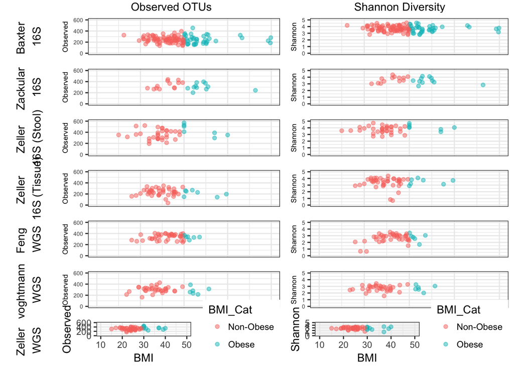

```r
# ggsave(supfig1a, file = "crc_bmi_supfig1.pdf", width=8, height=10, units=c("in"))

# Part B
supfig1b <- grid.arrange(
    p, xlab1, xlab2,
    ylab1,
    sp_CRC[[paste0("baxter",".Observed")]] + ptheme ,
    sp_CRC[[paste0("baxter", ".Shannon")]] + ptheme,
    ylab2,
    sp_CRC[[paste0("zackular", ".Observed")]] + ptheme,
    sp_CRC[[paste0("zackular", ".Shannon")]] + ptheme ,
    ylab3,
    sp_CRC[[paste0("zeller.Stool", ".Observed")]]  + ptheme ,
    sp_CRC[[paste0("zeller.Stool", ".Shannon")]] + ptheme  ,
    ylab4,
    sp_CRC[[paste0("zeller.Tissue", ".Observed")]] + ptheme  ,
    sp_CRC[[paste0("zeller.Tissue", ".Shannon")]] + ptheme,
    ylab5,
    sp_CRC[[paste0("feng", ".Observed")]] + ptheme  ,
    sp_CRC[[paste0("feng", ".Shannon")]] + ptheme ,
    ylab6,
    sp_CRC[[paste0("voghtmann", ".Observed")]] + ptheme,
    sp_CRC[[paste0("voghtmann", ".Shannon")]] + ptheme,
    ylab7,
    sp_CRC[[paste0("zeller.WGS", ".Observed")]],
    sp_CRC[[paste0("zeller.WGS", ".Shannon")]] ,
    ncol = 3, widths = gwidths, heights = gheights)
```

```r
# ggsave(supfig1b, file = "crc_bmi_supfig1b.pdf", width=8, height=10, units=c("in"))
```

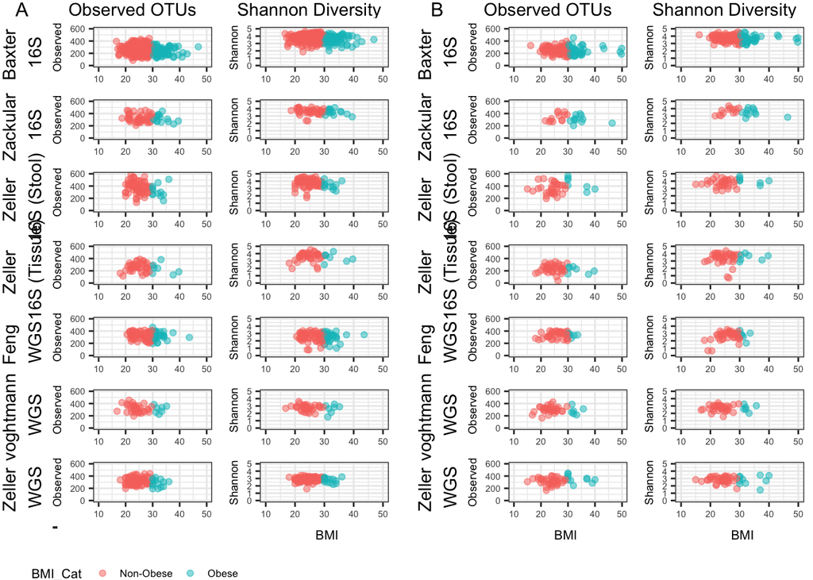

```r
p1 <- textGrob("A", gp=gpar(fontsize=12, col="black"))
p2 <- textGrob("B", gp=gpar(fontsize=12, col="black"))

xlab0 <- textGrob("          BMI", gp=gpar(fontsize=8, col="black"))

ptheme <- theme(text = element_text(size=7),
                legend.position = "none",
                axis.title.x = element_blank())
ptheme1 <- theme(text = element_text(size=8),
                legend.position = "bottom",
                axis.title.x = element_blank(),
                axis.title.y = element_blank(),
                axis.text.x = element_blank(),
                axis.text.y = element_blank(),
                axis.ticks.x = element_blank())
# defining grob formating
gwidths <- c(unit(.25, "mm"), rep(unit(1,"in"), 2),unit(.1, "mm"), unit(.25, "mm"), rep(unit(1,"in"), 2)) # 6 columns
gheights <- c(unit(.25, "mm"), rep(unit(1,"in"), 6), unit(1,"in"), unit(.25, "mm"), unit(.5,"in")) # 8 rows

# Combined:
supfig1 <- grid.arrange(
    p1, xlab1, xlab2,BLANK, p2, xlab1, xlab2,

    ylab1,
    sp_nonCRC[[paste0("baxter",".Observed")]] + ptheme,
    sp_nonCRC[[paste0("baxter", ".Shannon")]] + ptheme,
    BLANK,
    ylab1,
    sp_CRC[[paste0("baxter",".Observed")]] + ptheme,
    sp_CRC[[paste0("baxter", ".Shannon")]] + ptheme,

    ylab2,
    sp_nonCRC[[paste0("zackular", ".Observed")]] + ptheme ,
    sp_nonCRC[[paste0("zackular", ".Shannon")]] + ptheme ,
    BLANK,
    ylab2,
    sp_CRC[[paste0("zackular", ".Observed")]] + ptheme ,
    sp_CRC[[paste0("zackular", ".Shannon")]] + ptheme ,

    ylab3,
    sp_nonCRC[[paste0("zeller.Stool", ".Observed")]] + ptheme ,
    sp_nonCRC[[paste0("zeller.Stool", ".Shannon")]] + ptheme ,
    BLANK,
    ylab3,
    sp_CRC[[paste0("zeller.Stool", ".Observed")]] + ptheme ,
    sp_CRC[[paste0("zeller.Stool", ".Shannon")]] + ptheme ,

    ylab4,
    sp_nonCRC[[paste0("zeller.Tissue", ".Observed")]] + ptheme ,
    sp_nonCRC[[paste0("zeller.Tissue", ".Shannon")]] + ptheme,
    BLANK,
    ylab4,
    sp_CRC[[paste0("zeller.Tissue", ".Observed")]] + ptheme ,
    sp_CRC[[paste0("zeller.Tissue", ".Shannon")]] + ptheme,

    ylab5,
    sp_nonCRC[[paste0("feng", ".Observed")]] + ptheme ,
    sp_nonCRC[[paste0("feng", ".Shannon")]] + ptheme,
    BLANK,
    ylab5,
    sp_CRC[[paste0("feng", ".Observed")]] + ptheme ,
    sp_CRC[[paste0("feng", ".Shannon")]] + ptheme,

    ylab6,
    sp_nonCRC[[paste0("voghtmann", ".Observed")]] + ptheme ,
    sp_nonCRC[[paste0("voghtmann", ".Shannon")]] + ptheme,
    BLANK,
    ylab6,
    sp_CRC[[paste0("voghtmann", ".Observed")]] + ptheme ,
    sp_CRC[[paste0("voghtmann", ".Shannon")]] + ptheme,

    ylab7,
    sp_nonCRC[[paste0("zeller.WGS", ".Observed")]]+ ptheme,
    sp_nonCRC[[paste0("zeller.WGS", ".Shannon")]] + ptheme,
    BLANK,
    ylab7,
    sp_CRC[[paste0("zeller.WGS", ".Observed")]] + ptheme,
    sp_CRC[[paste0("zeller.WGS", ".Shannon")]] + ptheme,
    BLANK, xlab0, xlab0, BLANK,BLANK, xlab0, xlab0,

    BLANK, sp_CRC[[paste0("zeller.WGS", ".Shannon")]] + ptheme1,
    BLANK,BLANK,BLANK,BLANK,BLANK,

    ncol = 7, widths = gwidths, heights = gheights
)
```

```r
ggsave(supfig1, file = "crc_bmi_supfig1.pdf", width=7, height=7, units=c("in"))
```